# Install packages

```
install.packages('ggthemes', dependencies = TRUE)
install.packages('ggplot2', dependencies = TRUE)
install.packages('knitr', dependencies = TRUE)
```

```r
library(ggplot2)
library(ggthemes)
library(knitr)
```

### Change directory - get Facebook data

```r
setwd("~/Dropbox/Udacity/NanoDA/EDAwithR/EDA_Course_Materials/lesson3")
pf <- read.delim('pseudo_facebook.tsv')
```

# Data of birth plot

## First create with breaks

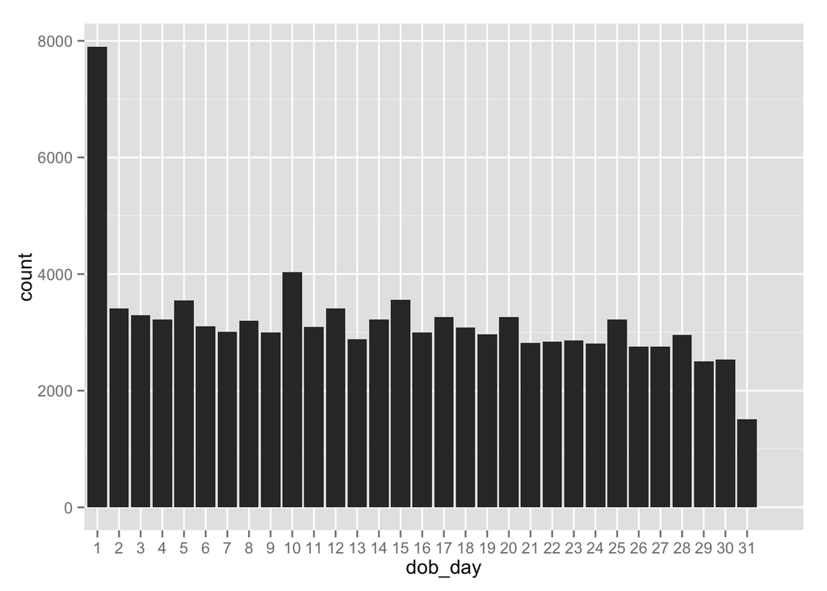

```r
ggplot(aes(x = dob_day), data = pf) +
  geom_histogram() +
  scale_x_discrete(breaks = 1:31)
```

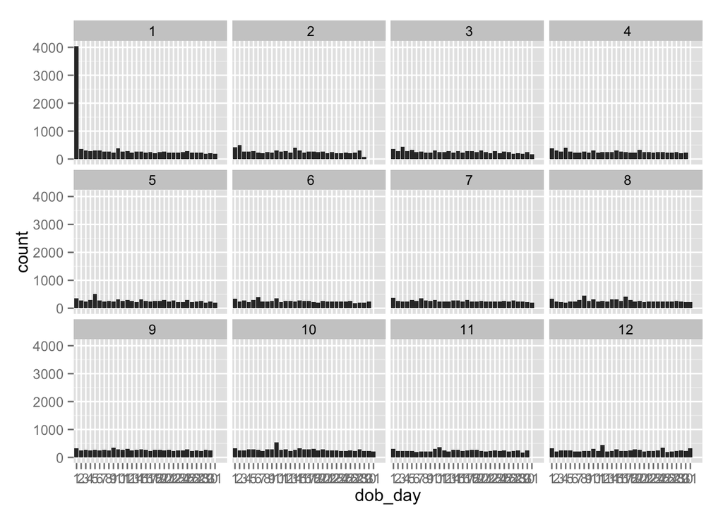

```r
ggplot(data = pf, aes(x = dob_day)) +
  geom_histogram() +
  scale_x_discrete(breaks = 1:31) +
  facet_wrap(~dob_month)
```

# Plot Friend Count Facebook data

```r
names(pf)
```

```
##  [1] "userid"                "age"
##  [3] "dob_day"               "dob_year"
##  [5] "dob_month"             "gender"
##  [7] "tenure"                "friend_count"
##  [9] "friendships_initiated" "likes"
## [11] "likes_received"        "mobile_likes"
## [13] "mobile_likes_received" "www_likes"
## [15] "www_likes_received"
```

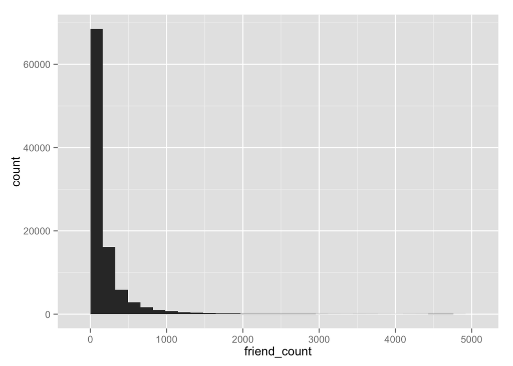

```r
qplot(x = friend_count, data = pf)
```

## answer in ggplot form

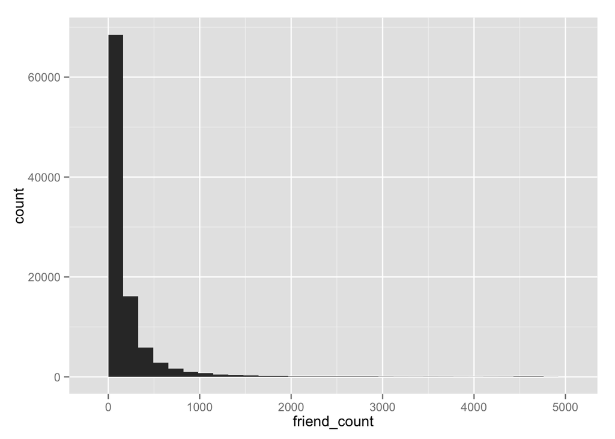

```r
ggplot(aes(x = friend_count), data = pf) +
  geom_histogram()
```

## Plot friend count with different binwidth/setting x scale with breaks (split gender into different plots)

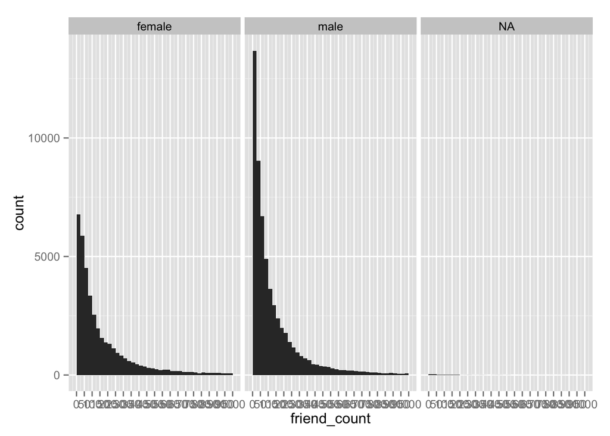

```r
qplot(x = friend_count, data = pf, binwidth = 25) +
  scale_x_continuous(limits = c(0, 1000), breaks = seq(0, 1000, 50)) +
facet_wrap(~gender)
```

## alternative answer using facet_grid

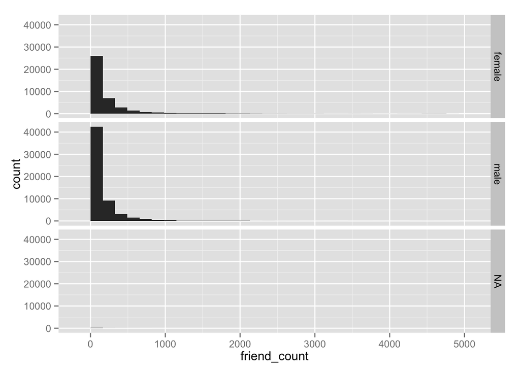

```r
qplot(x = friend_count, data = pf) +
  facet_grid(gender ~ .)
```

## alternative answer in ggplot2

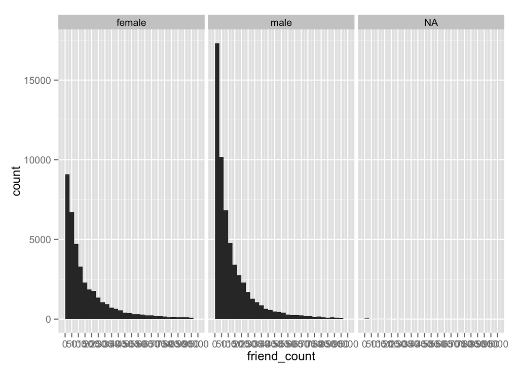

```r
ggplot(aes(x = friend_count), data = pf) +
  geom_histogram() +
  scale_x_continuous(limits = c(0, 1000), breaks = seq(0, 1000, 50)) +
  facet_wrap(~gender)
```

## NA values - http://www.statmethods.net/input/missingdata.html

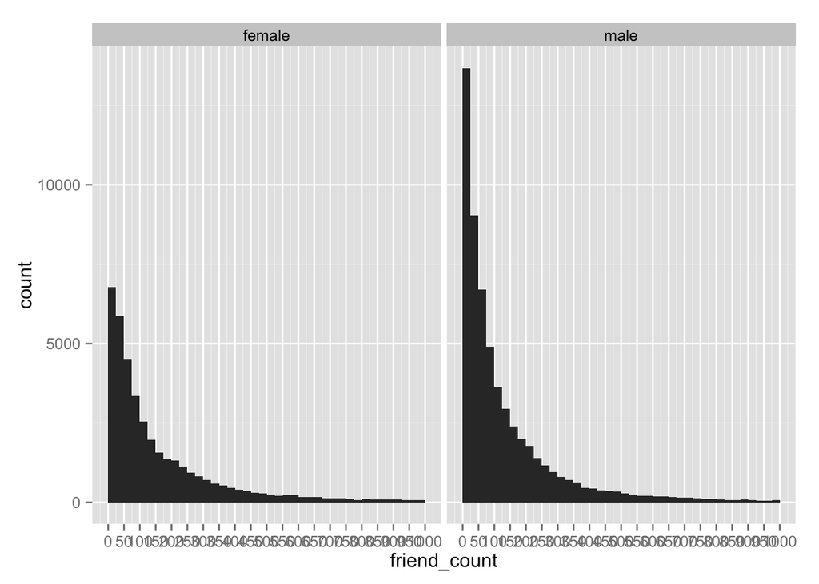

```r
qplot(x = friend_count, data = subset(pf, !is.na(gender)), binwidth = 25) +
  scale_x_continuous(limits = c(0, 1000), breaks = seq(0, 1000, 50)) +
  facet_wrap(~gender)
```

## another way to deal with Na values - caution: more dangerous as it will omit # NA values in other variables, not only gender

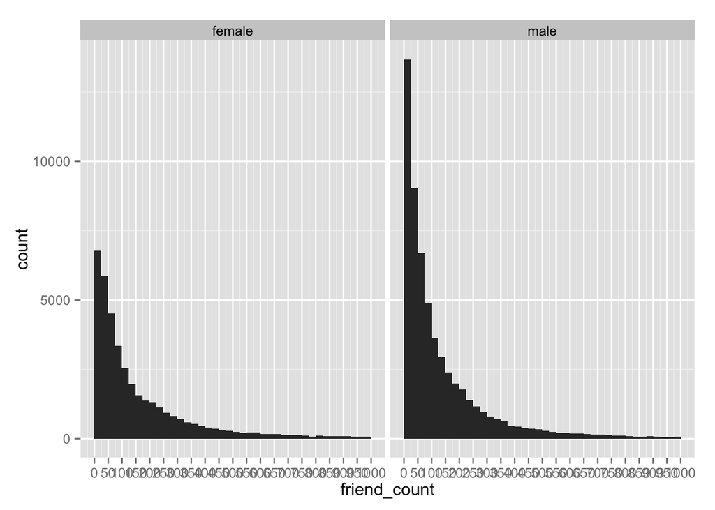

```r
qplot(x = friend_count, data = na.omit(pf), binwidth = 25) +
  scale_x_continuous(limits = c(0, 1000), breaks = seq(0, 1000, 50)) +
  facet_wrap(~gender)
```

## in ggplot2

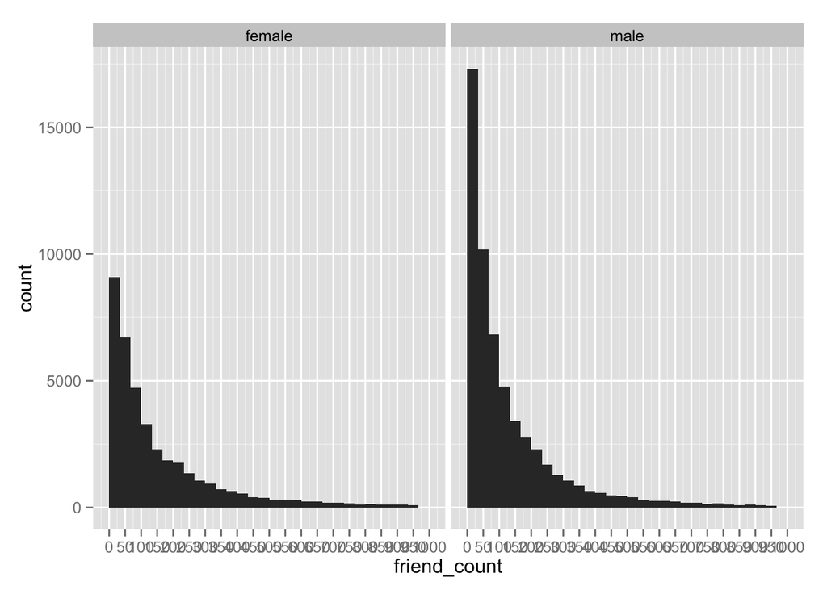

```r
ggplot(aes(x = friend_count), data = subset(pf, !is.na(gender))) +
  geom_histogram() +
  scale_x_continuous(limits = c(0, 1000), breaks = seq(0, 1000, 50)) +
  facet_wrap(~gender)
```

# Statistics ‘by’ Gender Solution

```r
by(pf$friend_count, pf$gender, summary)
```

```
## pf$gender: female
##    Min. 1st Qu.  Median    Mean 3rd Qu.    Max.
##       0      37      96     242     244    4923
## --------------------------------------------------------
## pf$gender: male
##    Min. 1st Qu.  Median    Mean 3rd Qu.    Max.
##       0      27      74     165     182    4917
```

The parameter color determines the color outline of objects in a plot. The parameter fill determines the color of the area inside objects in a plot. You might notice how the color black and the hex code color of #099DD9 (a shade of blue) are wrapped inside of I(). The I() functions stand for ‘as is’ and tells qplot to use them as colors.

# ggplot2 docs on themes: http://docs.ggplot2.org/0.9.2.1/theme.html

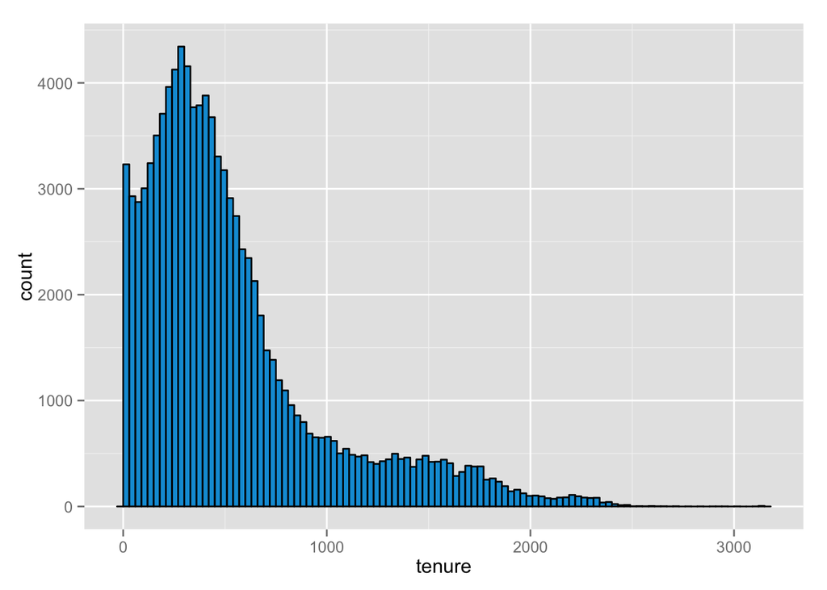

```r
ggplot(aes(x = tenure), data = pf) +
  geom_histogram(binwidth = 30, color = 'black', fill = '#099DD9')
```

# Tenure

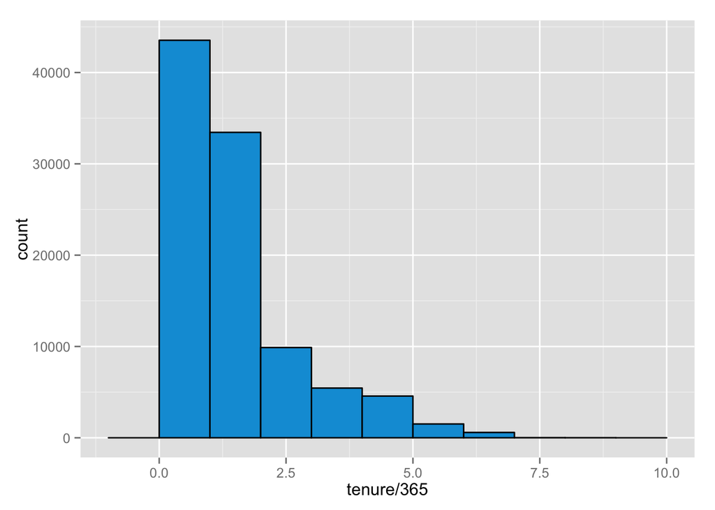

```r
qplot(x = tenure/365, data = pf, binwidth = 1, color = I('black'), fill = I('#099DD9'))
```

# Improved plot

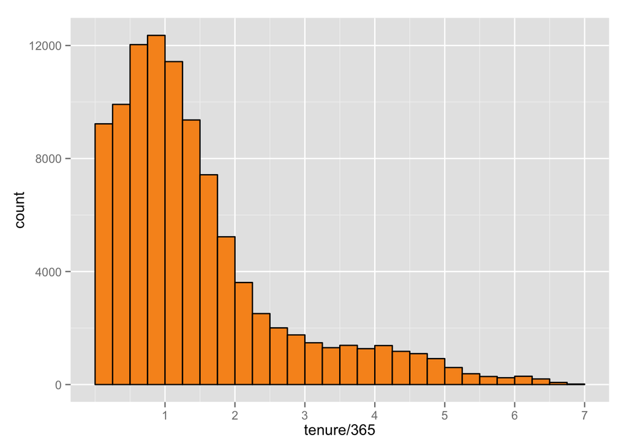

```r
qplot(x = tenure/365, data = pf, binwidth = .25, color = I('black'), fill = I('#F79420')) +
  scale_x_continuous(breaks = seq (1, 7, 1), lim = c(0,7)) # makes breaks go from 0-7
```

## ggplot2 equivalent

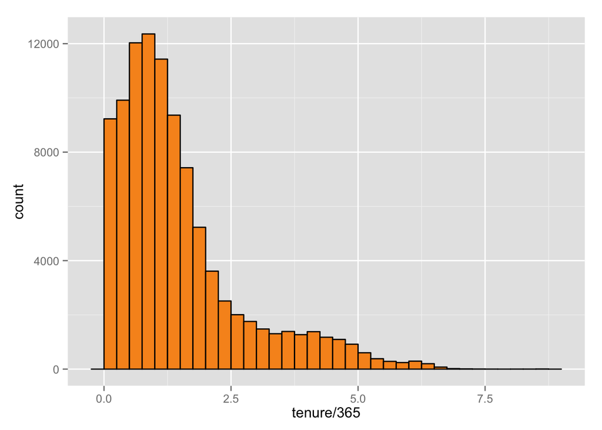

```r
ggplot(aes(x = tenure/365), data = pf) +
  geom_histogram(binwidth = .25, color = 'black', fill = '#F79420')
```

# Adding labels to plots

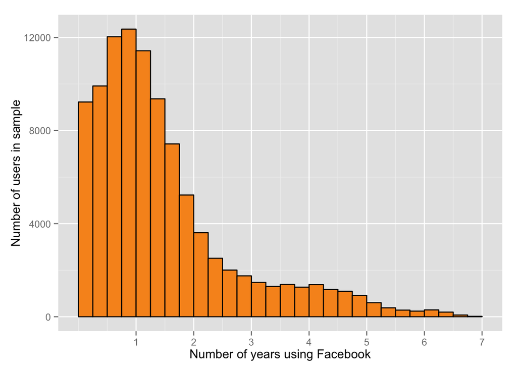

```r
qplot(x = tenure/365, data = pf, binwidth = .25, color = I('black'), fill = I('#F79420'),
  xlab = "Number of years using Facebook",
  ylab = "Number of users in sample") +
  scale_x_continuous(breaks = seq (1, 7, 1), lim = c(0,7)) # makes breaks go from 0-7
```

# Add nice labels to the plot ## ggplot2 version

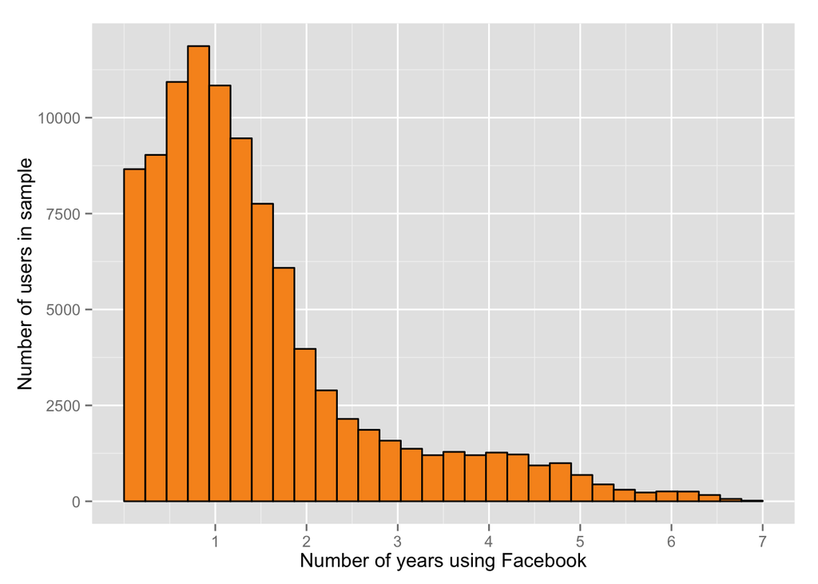

```r
ggplot(aes(x = tenure / 365), data = pf) +
  geom_histogram(color = 'black', fill = '#F79420') +
  scale_x_continuous(breaks = seq(1, 7, 1), limits = c(0, 7)) +
  xlab('Number of years using Facebook') +
  ylab('Number of users in sample')
```

# Exercise to create Histogram of ages from pf dataset

```r
names(pf)
```

```
##  [1] "userid"                "age"
##  [3] "dob_day"               "dob_year"
##  [5] "dob_month"             "gender"
##  [7] "tenure"                "friend_count"
##  [9] "friendships_initiated" "likes"
## [11] "likes_received"        "mobile_likes"
## [13] "mobile_likes_received" "www_likes"
## [15] "www_likes_received"
```

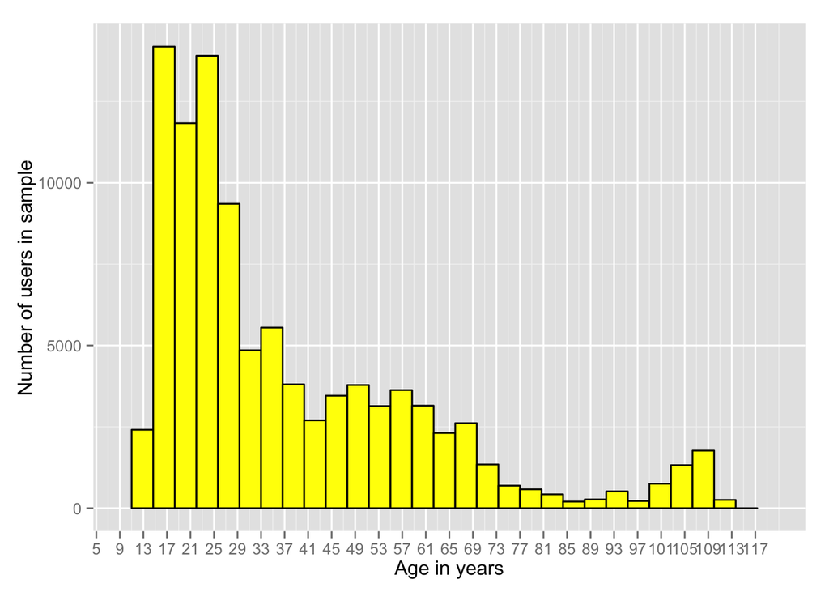

```r
ggplot(aes(x = age), data = pf) +
  geom_histogram( color = 'black', fill = 'yellow') +
  scale_x_continuous(breaks = seq(1, 120, 4), limits = c(10,120)) +
  xlab("Age in years") +
  ylab("Number of users in sample")
```

## Instructor’s plot

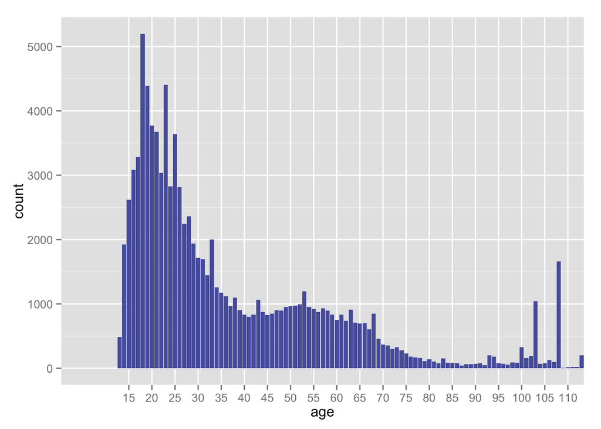

```r
ggplot(aes(x = age), data = pf) +
  geom_histogram(binwidth = 1, fill = '#5760AB') +
  scale_x_discrete(breaks = seq(0, 113, 5))
```

# Exercise to use scales and create multiple plots on one page. Use log10 & sqrt

Tips about transforming data with log base 10 and log base 2: [R-stats blog](http://www.r-statistics.com/2013/05/log-transformations-for-skewed-and-wide-distributions-from-practical-data-science-with-r/)

```
signedlog10 = function(x) {
ifelse(abs(x) <= 1, 0, sign(x)*log10(abs(x)))
}
```

```
install.packages('gridExtra')
```

```r
library(gridExtra)
```

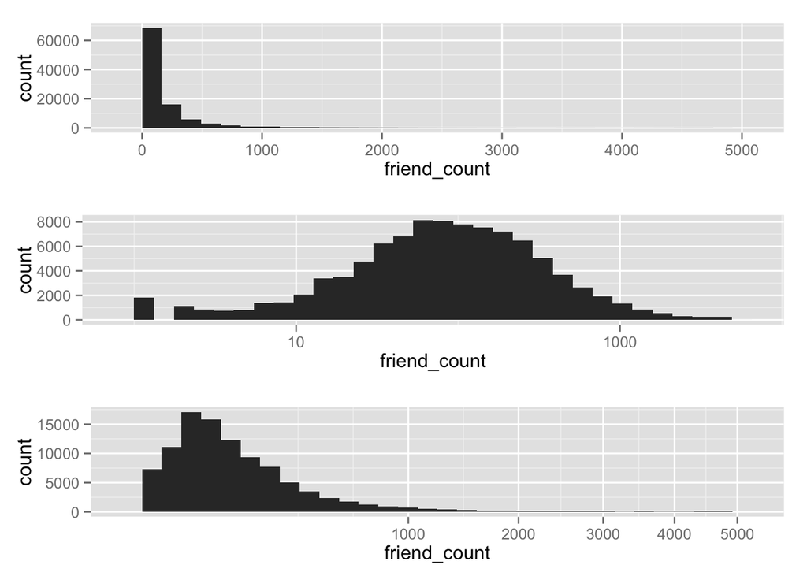

```r
p1 <- ggplot(aes(x = friend_count), data = pf) +
  geom_histogram()
p2 <- ggplot(aes(x = friend_count), data = pf) +
  geom_histogram() +
  scale_x_log10()  # use scale_x_log10 instead of calculating log10 wrapper so x-axis has actual x values
p3 <- ggplot(aes(x = friend_count), data = pf) +
  geom_histogram() +
  scale_x_sqrt()
grid.arrange(p1, p2, p3, ncol=1)
```

### Note instructor’s answers with qplot

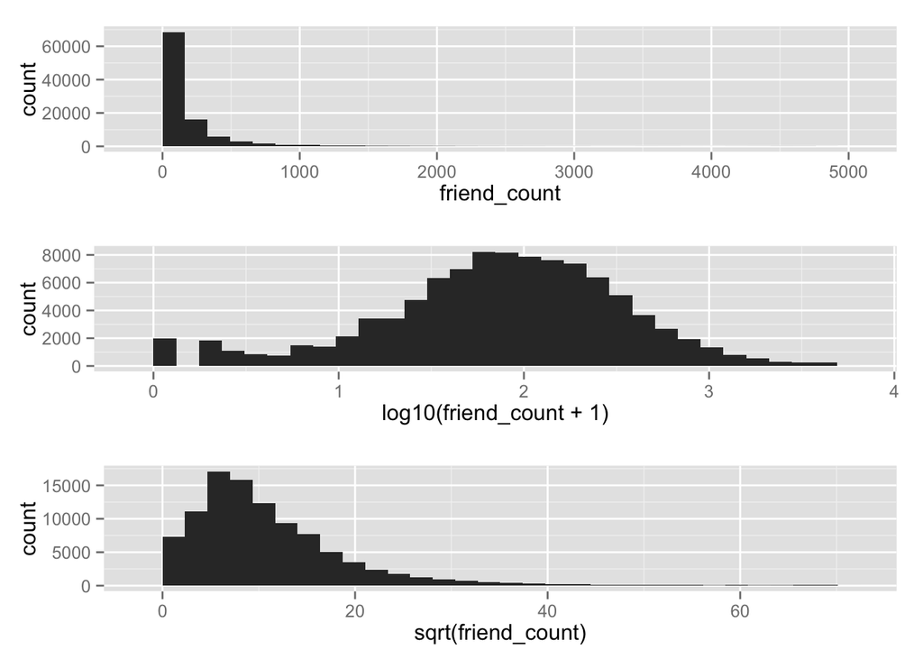

```r
q1 <- qplot(x = friend_count, data = pf)
# Adding +1 helps deal with -Infinity and Infinity as log10 approaches 0
q2 <- qplot(x = log10(friend_count + 1), data = pf)
q3 <- qplot(x = sqrt(friend_count), data = pf)
grid.arrange(q1, q2, q3, ncol=1)
```

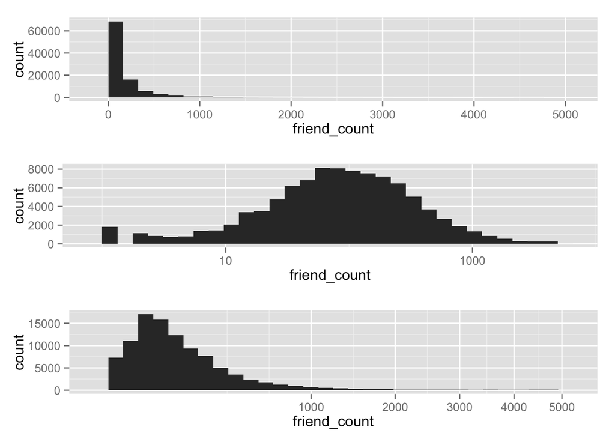

```r
# With the ggplot syntax, I can just use the original plot and add the log10 or sqrt function:
r1 <- ggplot(aes(x = friend_count), data = pf) +
  geom_histogram()
r2 <- r1 + scale_x_log10()
r3 <- r1 + scale_x_sqrt()
# super convenient & saved me so many lines
grid.arrange(r1, r2, r3, ncol=1)
```

# Frequency polygons

## Create freqpoly to see the shapes and peaks of the data.

Freqpoly allows side-by-side comparison with several curves stacked on top of each other

?qplot

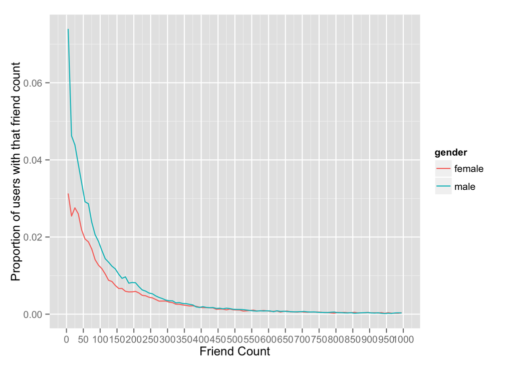

```r
qplot(x = friend_count, y = ..count../sum(..count..),
      data = subset(pf, !is.na(gender)),
      xlab = 'Friend Count',
      ylab = 'Proportion of users with that friend count',
      binwidth = 10, geom = 'freqpoly', color = gender) +
  scale_x_continuous(lim = c(0, 1000), breaks = seq(0, 1000, 50))
```

## Frequency polygons for which gender makes more likes on world wide web

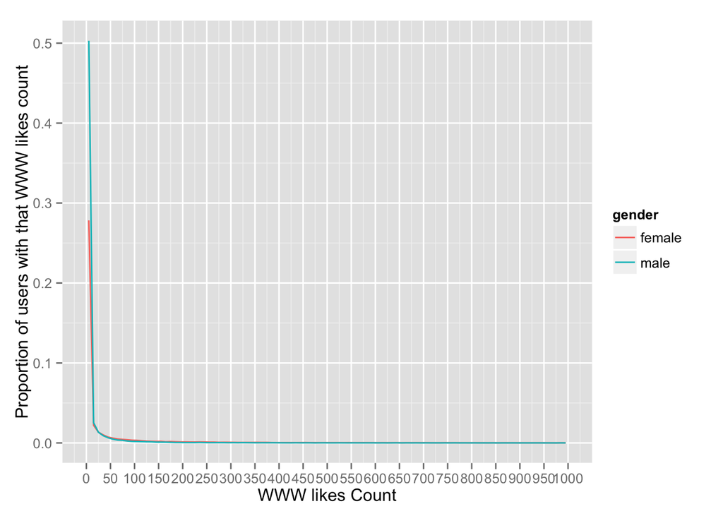

```r
qplot(x = www_likes, y = ..count../sum(..count..),
      data = subset(pf, !is.na(gender)),
      xlab = 'WWW likes Count',
      ylab = 'Proportion of users with that WWW likes count',
      binwidth = 10, geom = 'freqpoly', color = gender) +
  scale_x_continuous(lim = c(0, 1000), breaks = seq(0, 1000, 50))
```

### Iterate to find best limits & xbreaks (full likes)

```r
summary(pf$www_likes)
```

```
##     Min.  1st Qu.   Median     Mean  3rd Qu.     Max.
##     0.00     0.00     0.00    49.96     7.00 14860.00
```

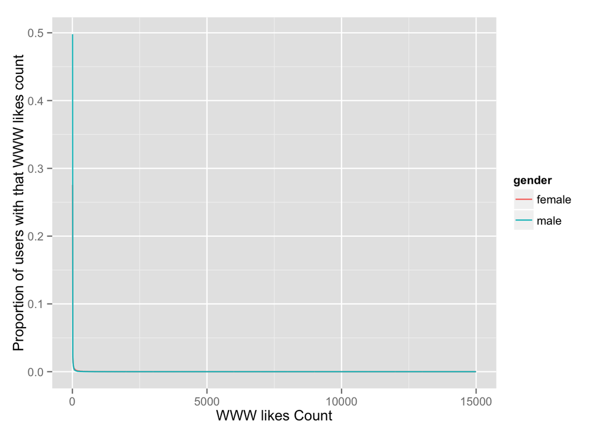

```r
qplot(x = www_likes, y = ..count../sum(..count..),
      data = subset(pf, !is.na(gender)),
      xlab = 'WWW likes Count',
      ylab = 'Proportion of users with that WWW likes count',
      binwidth = 10, geom = 'freqpoly', color = gender) +
  scale_x_continuous(lim = c(0, 15000), breaks = seq(0, 15000, 5000))
```

```r
summary(pf$www_likes)
```

```
##     Min.  1st Qu.   Median     Mean  3rd Qu.     Max.
##     0.00     0.00     0.00    49.96     7.00 14860.00
```

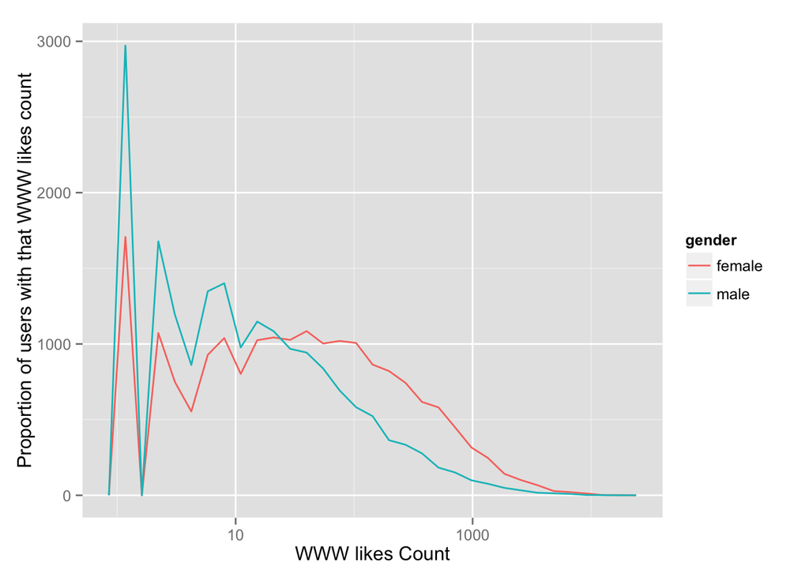

```r
qplot(x = www_likes,
      data = subset(pf, !is.na(gender)),
      xlab = 'WWW likes Count',
      ylab = 'Proportion of users with that WWW likes count',
      geom = 'freqpoly', color = gender) +
  scale_x_log10()
```

```r
  #scale_x_continuous(lim = c(0, 8), breaks = seq(0, 8, 1))
```

## Instructor’s plot answer in ggplot2

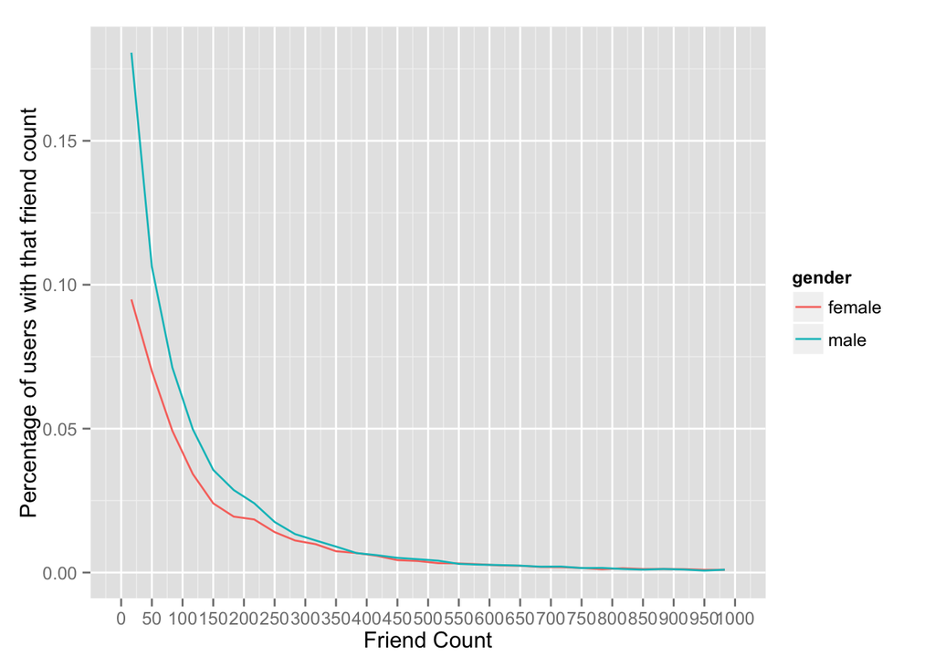

```r
ggplot(aes(x = friend_count, y = ..count../sum(..count..)), data = subset(pf, !is.na(gender))) +
  geom_freqpoly(aes(color = gender)) +
  scale_x_continuous(limits = c(0, 1000), breaks = seq(0, 1000, 50)) +
  xlab('Friend Count') +
  ylab('Percentage of users with that friend count')
```

chooseCRANmirror() options(“repos”)